# TreeClassification-HighRes

Aitor Apaolaza

09/01/2016

*Copyright (c) 2015 The University of Manchester, UK.*

*Licenced under LGPL version 2.1. See LICENCE for details.*

*The IDInteraction Processing Pipelines were developed in the IDInteraction project, funded by the Engineering and Physical Sciences Research Council, UK through grant agreement number EP/M017133/1.*

*Author: Aitor Apaolaza*

## Initialisation and loading data

```
## [1] "All listed packages are already installed"
```

# Setup for the classification algorithm.

**Folder**: /home/aitor/Dropbox/UoM/IDInteractionCode/Rnotebooks

**Experiment**: dual_screen_free_experiment

**Source Videos**: high_quality

**Tracking system**: front_eyes_only

**Using the following list of participants**: P01, P03, P04, P05, P06, P08, P09, P10, P12.

Data for these participants will be read from the CSV files contained in the following folders:

/home/aitor/Dropbox/UoM/IDInteractionCode/Rnotebooks/resources/dual_screen_free_experiment/high_quality/attention/

/home/aitor/Dropbox/UoM/IDInteractionCode/Rnotebooks/resources/dual_screen_free_experiment/high_quality/front_eyes_only/

Loading data

```
## [1] "Processing participant: P01"
## [1] "START of combineCSVsToDF()"
## [1] "END of combineCSVsToDF()"
## [1] "START of createFeatureDF()"
## [1] "END of createFeatureDF()"
## [1] "Processing participant: P03"
## [1] "START of combineCSVsToDF()"
## [1] "END of combineCSVsToDF()"
## [1] "START of createFeatureDF()"
## [1] "END of createFeatureDF()"
## [1] "Processing participant: P04"
## [1] "START of combineCSVsToDF()"
## [1] "END of combineCSVsToDF()"
## [1] "START of createFeatureDF()"
## [1] "END of createFeatureDF()"
```

[output cut: 30 more lines]

From a total of 408944 rows, 2/3 of them (273748) will be used for training, and 1/3 for testing (135196).

## Training the tree classifier

Using the **rpart** library for the following formula:

**attentionName ~ boxHeight + boxRotation + boxArea + boxWidth + widthHeightRatio + boxYcoordRel**

Resulting model:

```
## n= 273748
##
## node), split, n, loss, yval, (yprob)
##       * denotes terminal node
##
##   1) root 273748 85515 tv (0.3121082163 0.6876141561 0.0002776276)
##     2) boxYcoordRel>=0.5528174 49028 14472 ipad (0.7048217345 0.2951782655 0.0000000000)
##       4) widthHeightRatio>=0.3513533 23575  2778 ipad (0.8821633086 0.1178366914 0.0000000000)
##         8) boxHeight< 16.00745 19833   443 ipad (0.9776634901 0.0223365099 0.0000000000) *
##         9) boxHeight>=16.00745 3742  1407 tv (0.3760021379 0.6239978621 0.0000000000) *
##       5) widthHeightRatio< 0.3513533 25453 11694 ipad (0.5405649629 0.4594350371 0.0000000000)
##        10) widthHeightRatio< 0.3123828 3843   244 ipad (0.9365079365 0.0634920635 0.0000000000) *
##        11) widthHeightRatio>=0.3123828 21610 10160 tv (0.4701527071 0.5298472929 0.0000000000)
##          22) boxHeight>=40.89615 4105  1019 ipad (0.7517661389 0.2482338611 0.0000000000) *
##          23) boxHeight< 40.89615 17505  7074 tv (0.4041131105 0.5958868895 0.0000000000)
##            46) boxYcoordRel>=0.621608 5509  2222 ipad (0.5966600109 0.4033399891 0.0000000000) *
##            47) boxYcoordRel< 0.621608 11996  3787 tv (0.3156885629 0.6843114371 0.0000000000) *
##     3) boxYcoordRel< 0.5528174 224720 50959 tv (0.2264284443 0.7732333571 0.0003381986)
##       6) boxArea< 578.5353 127847 38406 tv (0.2998114934 0.6995940460 0.0005944606)
##        12) boxRotation>=0.01528255 28085 13430 tv (0.4781912053 0.5218087947 0.0000000000)
##          24) boxYcoordRel>=0.1192772 20848  8510 ipad (0.5918073676 0.4081926324 0.0000000000)
##            48) boxHeight< 13.56185 11700  2651 ipad (0.7734188034 0.2265811966 0.0000000000) *
##            49) boxHeight>=13.56185 9148  3289 tv (0.3595321382 0.6404678618 0.0000000000)
##              98) boxYcoordRel>=0.413515 2399   470 ipad (0.8040850354 0.1959149646 0.0000000000) *
##              99) boxYcoordRel< 0.413515 6749  1360 tv (0.2015113350 0.7984886650 0.0000000000) *
##          25) boxYcoordRel< 0.1192772 7237  1092 tv (0.1508912533 0.8491087467 0.0000000000) *
##        13) boxRotation< 0.01528255 99762 24976 tv (0.2495940338 0.7496441531 0.0007618131)
##          26) widthHeightRatio< 0.3437481 15374  6352 tv (0.4131650839 0.5868349161 0.0000000000)
##            52) boxYcoordRel>=0.05904361 10964  4726 ipad (0.5689529369 0.4310470631 0.0000000000)
##             104) boxWidth< 41.0839 5867  1298 ipad (0.7787625703 0.2212374297 0.0000000000) *
##             105) boxWidth>=41.0839 5097  1669 tv (0.3274475181 0.6725524819 0.0000000000) *
##            53) boxYcoordRel< 0.05904361 4410   114 tv (0.0258503401 0.9741496599 0.0000000000) *
##          27) widthHeightRatio>=0.3437481 84388 18624 tv (0.2197942835 0.7793051145 0.0009006020)
##            54) boxYcoordRel>=0.2768439 35157 10750 tv (0.3054014848 0.6942287453 0.0003697699)
##             108) widthHeightRatio>=0.3888907 19302  9339 tv (0.4831623666 0.5161641281 0.0006735053)
##               216) boxArea>=192.0343 7549  1924 ipad (0.7451318055 0.2548681945 0.0000000000) *
##               217) boxArea< 192.0343 11753  3714 tv (0.3148983238 0.6839955756 0.0011061006)
##                 434) boxYcoordRel< 0.4961035 9070  3585 tv (0.3938257993 0.6047409041 0.0014332966)
##                   868) boxYcoordRel>=0.3503453 2077   182 ipad (0.9123736158 0.0876263842 0.0000000000) *
##                   869) boxYcoordRel< 0.3503453 6993  1690 tv (0.2398112398 0.7583297583 0.0018590019) *
##                 435) boxYcoordRel>=0.4961035 2683   129 tv (0.0480805069 0.9519194931 0.0000000000) *
##             109) widthHeightRatio< 0.3888907 15855  1411 tv (0.0889940082 0.9110059918 0.0000000000) *
##            55) boxYcoordRel< 0.2768439 49231  7874 tv (0.1586601938 0.8400601247 0.0012796815) *
##       7) boxArea>=578.5353 96873 12553 tv (0.1295820301 0.8704179699 0.0000000000)
##        14) widthHeightRatio>=0.4193564 23752  7002 tv (0.2947962277 0.7052037723 0.0000000000)
##          28) boxYcoordRel>=0.4038213 7451  2331 ipad (0.6871560864 0.3128439136 0.0000000000) *
##          29) boxYcoordRel< 0.4038213 16301  1882 tv (0.1154530397 0.8845469603 0.0000000000) *
##        15) widthHeightRatio< 0.4193564 73121  5551 tv (0.0759152637 0.9240847363 0.0000000000) *
```

From the R manual for the Complexity Parameter Table for an Rpart Fit: *The cptable in the fit contains the mean and standard deviation of the errors in the cross-validated prediction against each of the geometric means.*

Matrix of information on the optimal prunings based on a complexity parameter.

```
##
## Classification tree:
## rpart(formula = formula, data = trainsetclass, method = "class")
##
## Variables actually used in tree construction:
## [1] boxArea          boxHeight        boxRotation      boxWidth
## [5] boxYcoordRel     widthHeightRatio
##
## Root node error: 85515/273748 = 0.31239
##
## n= 273748
##
##         CP nsplit rel error  xerror      xstd
## 1 0.234859      0   1.00000 1.00000 0.0028356
## 2 0.015476      1   0.76514 0.76556 0.0026099
## 3 0.013588      8   0.64065 0.64164 0.0024493
## 4 0.013085     14   0.55912 0.55434 0.0023151
## 5 0.012454     17   0.51986 0.51966 0.0022562
## 6 0.010852     18   0.50741 0.51309 0.0022446
## 7 0.010016     19   0.49656 0.49885 0.0022191
## 8 0.010000     21   0.47652 0.48714 0.0021977
```

Visualisation of the Complexity Parameter Table. *A good choice of cp for pruning is often the leftmost value for which the mean lies below the horizontal line.*

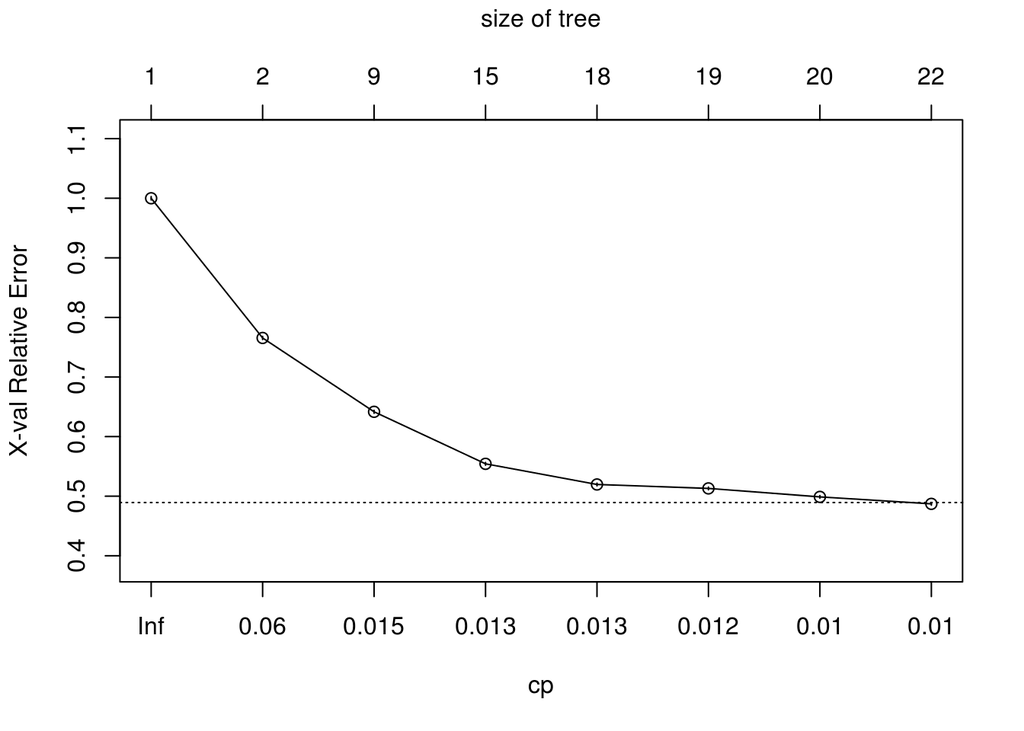

## Tree

### Summary of the tree

```
##
## Model formula:
## attentionName ~ boxHeight + boxRotation + boxArea + boxWidth +
##     widthHeightRatio + boxYcoordRel
##
## Fitted party:
## [1] root
## |   [2] boxYcoordRel >= 0.55282
## |   |   [3] widthHeightRatio >= 0.35135
## |   |   |   [4] boxHeight < 16.00745: ipad (n = 19833, err = 2.2%)
## |   |   |   [5] boxHeight >= 16.00745: tv (n = 3742, err = 37.6%)
## |   |   [6] widthHeightRatio < 0.35135
## |   |   |   [7] widthHeightRatio < 0.31238: ipad (n = 3843, err = 6.3%)
## |   |   |   [8] widthHeightRatio >= 0.31238
## |   |   |   |   [9] boxHeight >= 40.89615: ipad (n = 4105, err = 24.8%)
## |   |   |   |   [10] boxHeight < 40.89615
## |   |   |   |   |   [11] boxYcoordRel >= 0.62161: ipad (n = 5509, err = 40.3%)
## |   |   |   |   |   [12] boxYcoordRel < 0.62161: tv (n = 11996, err = 31.6%)
## |   [13] boxYcoordRel < 0.55282
## |   |   [14] boxArea < 578.53529
## |   |   |   [15] boxRotation >= 0.01528
## |   |   |   |   [16] boxYcoordRel >= 0.11928
## |   |   |   |   |   [17] boxHeight < 13.56185: ipad (n = 11700, err = 22.7%)
## |   |   |   |   |   [18] boxHeight >= 13.56185
## |   |   |   |   |   |   [19] boxYcoordRel >= 0.41352: ipad (n = 2399, err = 19.6%)
## |   |   |   |   |   |   [20] boxYcoordRel < 0.41352: tv (n = 6749, err = 20.2%)
## |   |   |   |   [21] boxYcoordRel < 0.11928: tv (n = 7237, err = 15.1%)
## |   |   |   [22] boxRotation < 0.01528
## |   |   |   |   [23] widthHeightRatio < 0.34375
## |   |   |   |   |   [24] boxYcoordRel >= 0.05904
## |   |   |   |   |   |   [25] boxWidth < 41.0839: ipad (n = 5867, err = 22.1%)
## |   |   |   |   |   |   [26] boxWidth >= 41.0839: tv (n = 5097, err = 32.7%)
## |   |   |   |   |   [27] boxYcoordRel < 0.05904: tv (n = 4410, err = 2.6%)
## |   |   |   |   [28] widthHeightRatio >= 0.34375
## |   |   |   |   |   [29] boxYcoordRel >= 0.27684
## |   |   |   |   |   |   [30] widthHeightRatio >= 0.38889
## |   |   |   |   |   |   |   [31] boxArea >= 192.03433: ipad (n = 7549, err = 25.5%)
## |   |   |   |   |   |   |   [32] boxArea < 192.03433
## |   |   |   |   |   |   |   |   [33] boxYcoordRel < 0.4961
## |   |   |   |   |   |   |   |   |   [34] boxYcoordRel >= 0.35035: ipad (n = 2077, err = 8.8%)
## |   |   |   |   |   |   |   |   |   [35] boxYcoordRel < 0.35035: tv (n = 6993, err = 24.2%)
## |   |   |   |   |   |   |   |   [36] boxYcoordRel >= 0.4961: tv (n = 2683, err = 4.8%)
## |   |   |   |   |   |   [37] widthHeightRatio < 0.38889: tv (n = 15855, err = 8.9%)
## |   |   |   |   |   [38] boxYcoordRel < 0.27684: tv (n = 49231, err = 16.0%)
## |   |   [39] boxArea >= 578.53529
## |   |   |   [40] widthHeightRatio >= 0.41936
## |   |   |   |   [41] boxYcoordRel >= 0.40382: ipad (n = 7451, err = 31.3%)
## |   |   |   |   [42] boxYcoordRel < 0.40382: tv (n = 16301, err = 11.5%)
## |   |   |   [43] widthHeightRatio < 0.41936: tv (n = 73121, err = 7.6%)
##
## Number of inner nodes:    21
## Number of terminal nodes: 22
```

### Visualisation of the tree

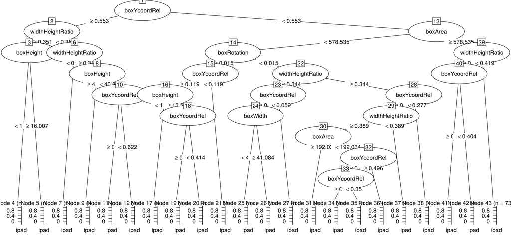

## Error metrics analysis

Confusion matrix from the application of the tree predictor to the testing set of data.

```
##            predclass
##              ipad    tv elsewhere
##   ipad      28441 13692         0
##   tv         6294 86729         0
##   elsewhere     0    40         0
```

### Error metrics based on prediction of attention to the iPad.

True negatives: 86729

True positives: 28441

**Error-rate**: the proportion of the incorrectly classified examples -> (fp+fn)/(tp+tn+fp+tn)

**14.7873568**

**Accuracy**: the proportion of the correctly classified examples -> (tp+tn)/(tp+tn+fp+tn)

**85.2126432**

As the number of instances of the response variable is not balanced (there are many more instances with false than true) the accuracy is not a good indicator. Other cost sensitive measures are reported here. -> cost sensitive measures

**Precision**: positive predicted value (PPV) -> tp/(tp+fp), a measure of exactness

**67.5029075**

**Recall/Sensitivity**: true positive recognition rate -> tp/(tp+fn), a measure of completeness

**81.8799482**

**Specificity**: true negative recognition rate -> tn/(tn+fp)

**86.3654017**

**F measure**: the balance between precision and recall -> 2*tp/(2*tp+fp+fn)

**73.9995837**

### Error metrics based on prediction of attention to the TV.

True negatives: 28441

True positives: 86729

**Error-rate**: the proportion of the incorrectly classified examples -> (fp+fn)/(tp+tn+fp+tn)

**14.7873568**

**Accuracy**: the proportion of the correctly classified examples -> (tp+tn)/(tp+tn+fp+tn)

**85.2126432**

**Precision**: positive predicted value (PPV) -> tp/(tp+fp), a measure of exactness

**93.2339314**

**Recall/Sensitivity**: true positive recognition rate -> tp/(tp+fn), a measure of completeness

**86.3654017**

**Specificity**: true negative recognition rate -> tn/(tn+fp)

**81.8799482**

**F measure**: the balance between precision and recall -> 2*tp/(2*tp+fp+fn)

**89.6683278**